# Week 6 — Develop First Modeling Approach

**Next-Month Domestic Airline Passenger-Demand Forecasting**

## ===== WEEK 6 START =====

**Assignment:** One method, three hyperparameter variations, training and validation metrics, choose a winner **only using validation data**.

**Proposed first model:** Ridge regression on the two Week 5 PCA predictors (`PC1`, `PC2`).

- This is a simple linear model ahead of potentially more complex methods in later weeks.
- We use the exact Week 3 chronological target and split logic.
- We do not evaluate the held-out test partition in Week 6.

The transformed input pipeline was fitted on the training period only. Predicted passenger counts are clipped at 0 for practical validity, consistently across all candidate models.

## 1. Import the Week 6 reusable source

Only one pipeline implements the calculations. This notebook calls `Src/week6_src_ridge_models.py`; no duplicate model logic is pasted into the notebook.

```python
from pathlib import Path
import importlib.util
import sys
from IPython.display import display, Image

def project_root(start=None):
    start = (start or Path.cwd()).resolve()
    for folder in [start, *start.parents]:
        if all((folder / name).is_dir() for name in ('Src', 'Data', 'Notebooks')):
            return folder
    raise FileNotFoundError('Repository root not found.')

ROOT = project_root()
SRC = ROOT / 'Src' / 'week6_src_ridge_models.py'
spec = importlib.util.spec_from_file_location('week6_ridge', SRC)
week6 = importlib.util.module_from_spec(spec)
sys.modules[spec.name] = week6
spec.loader.exec_module(week6)
REPORTS = ROOT / 'Reports' / 'week6'
TABLES = REPORTS / 'week6_tables'
FIGURES = REPORTS / 'week6_figures'
print('Root:', ROOT)
print('Source:', SRC)
print('Settings:', week6.MODEL_SETTINGS)
```

```
Root: C:\Users\king-\Desktop\ADAN8888 - AA Project\Module 2\3. Assignment1\2. Project Folder - GitHub
Source: C:\Users\king-\Desktop\ADAN8888 - AA Project\Module 2\3. Assignment1\2. Project Folder - GitHub\Src\week6_src_ridge_models.py
Settings: [('Ridge_A', 1.0), ('Ridge_B', 10000.0), ('Ridge_C', 1000000.0)]
```

## 2. Reconstruct Week 5 PCA inputs and Week 3 split

Reusing the Week 5 `Src/week5_src_features_dimensionality.py` creates the complete PC1/PC2 matrices from the **official BTS source archives**.

- The Week 5 PCA medians, scaler, and PCA components are fitted to training only.
- Previous Week 5 *sample CSVs* won't be used for model evaluation because they are only small previews.

```python
partitions, split_summary, input_source = week6._load_week5_data(ROOT)
print('Input source:', input_source)
display(split_summary)
print('Training rows:', len(partitions['Training']))
print('Validation rows:', len(partitions['Validation']))
assert len(partitions['Training']) > len(partitions['Validation']) > 0
assert partitions['Training']['ForecastMonth'].max() < partitions['Validation']['ForecastMonth'].min()
print('Training–validation chronology verified. Test outcomes not evaluated.')
```

```
Input source: Week 5 source (reconstructed full PCA from official BTS ZIPs)
```

|  | Split | Rows | ForecastMonths | FirstReferenceMonth | LastReferenceMonth | FirstForecastMonth | LastForecastMonth | RowPercent | MonthPercent |
| --- | --- | --- | --- | --- | --- | --- | --- | --- | --- |
| 0 | Training | 1062603 | 95 | 2015-01-01 | 2022-11-01 | 2015-02-01 | 2022-12-01 | 67.842078 | 69.852941 |
| 1 | Validation | 239395 | 20 | 2022-12-01 | 2024-07-01 | 2023-01-01 | 2024-08-01 | 15.284216 | 14.705882 |
| 2 | Test | 264291 | 21 | 2024-08-01 | 2026-04-01 | 2024-09-01 | 2026-05-01 | 16.873706 | 15.441176 |

```
Training rows: 1062603
Validation rows: 239395
Training–validation chronology verified. Test outcomes not evaluated.
```

## 3. Define three Ridge regularization strengths and evaluation measures

Ridge minimizes squared training errors with an additional coefficient penalty controlled by `alpha`. Stronger alpha shrinks coefficients more and may reduce overfitting at the cost of underfitting. The settings are deliberately spread across orders of magnitude, given the large training sample.

| Candidate | Alpha | Regularization level |
| --- | --- | --- |
| Ridge_A | 1 | Weak |
| Ridge_B | 10,000 | Moderate |
| Ridge_C | 1,000,000 | Strong |

**MAE** (passengers) is the primary selection metric because typical absolute deviation is easy for capacity planners to interpret. **RMSE** (passengers) penalizes large misses more heavily, and **R²** summarizes fit relative to predicting the mean. Metrics are calculated separately on **training and validation**. There is no hyperparameter search on the test data.

```python
results = week6.train_and_compare(
    partitions['Training'],
    partitions['Validation'],
    split_summary,
    data_source=input_source,
)
display(results.metrics_table.round(3))
assert results.metrics_long.shape[0] == 6
assert results.metrics_table.shape[0] == 3
assert set(results.metrics_long['Split']) == {'Training', 'Validation'}
```

|  | Model | Alpha | Training_MAE | Training_RMSE | Training_R2 | Validation_MAE | Validation_RMSE | Validation_R2 | MAE_Gap_ValidationMinusTraining |
| --- | --- | --- | --- | --- | --- | --- | --- | --- | --- |
| 0 | Ridge_A | 1.0 | 3331.959 | 5787.133 | 0.444 | 3257.177 | 5887.098 | 0.473 | -74.782 |
| 1 | Ridge_B | 10000.0 | 3332.425 | 5789.185 | 0.443 | 3259.035 | 5890.276 | 0.473 | -73.390 |
| 2 | Ridge_C | 1000000.0 | 3395.138 | 5985.650 | 0.405 | 3418.394 | 6163.435 | 0.422 | 23.256 |

## 4. Compare training-versus-validation errors

The difference between training and validation errors helps assess whether changing alpha improves generalization, though temporal drift may also contribute. A smaller training error is not sufficient grounds to select the winner.

```python
display(results.comparison.round(3))
print('Selected by lowest VALIDATION MAE:', results.winner, 'alpha:', results.winner_alpha)
```

|  | Model | Alpha | Validation_MAE | Validation_RMSE | Validation_R2 | MAE_Gap_ValidationMinusTraining |
| --- | --- | --- | --- | --- | --- | --- |
| 0 | Ridge_A | 1.0 | 3257.177 | 5887.098 | 0.473 | -74.782 |
| 1 | Ridge_B | 10000.0 | 3259.035 | 5890.276 | 0.473 | -73.390 |
| 2 | Ridge_C | 1000000.0 | 3418.394 | 6163.435 | 0.422 | 23.256 |

```
Selected by lowest VALIDATION MAE: Ridge_A alpha: 1.0
```

## 5. Save reproducible Week 6 tables, figures, and winning model

The winner is selected based on validation performance only. The selected estimator is saved in `Models/week6/`, with an associated JSON manifest describing its inputs and winning metrics. The saved estimator requires the matching Week 5 PCA transformation for future inference; it is not a stand-alone raw-data predictor.

```python
week6.save_outputs(results, ROOT)
for path in sorted(TABLES.glob('*')):
    print('TABLE:', path.name)
for path in sorted(FIGURES.glob('*.png')):
    print('FIGURE:', path.name)
print('MODEL:', ROOT / 'Models' / 'week6' / 'week6_selected_ridge.joblib')
```

```
TABLE: week6_metrics_train_validation_long.csv
TABLE: week6_models_metrics_comparison.csv
TABLE: week6_split_summary.csv
TABLE: week6_validation_ranking.csv
TABLE: week6_winner_summary.json
FIGURE: week6_figure_mae_by_alpha.png
FIGURE: week6_figure_rmse_by_alpha.png
FIGURE: week6_figure_validation_actual_vs_predicted.png
MODEL: C:\Users\king-\Desktop\ADAN8888 - AA Project\Module 2\3. Assignment1\2. Project Folder - GitHub\Models\week6\week6_selected_ridge.joblib
```

## 6. Inspect comparison and diagnostic figures

Validation actual-versus-predicted is sampled only for visualization. The MAE/RMSE/R² metrics above are computed using **all** training and validation rows.

```
week6_figure_mae_by_alpha.png
```

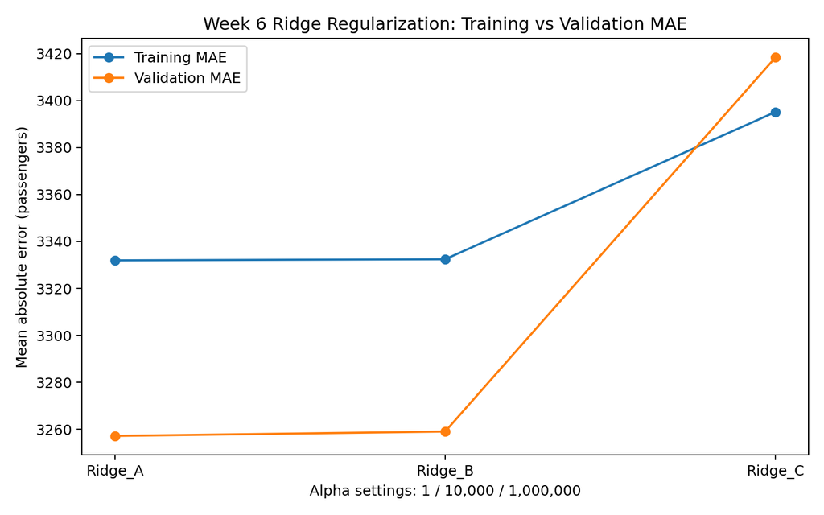

```
week6_figure_rmse_by_alpha.png
```

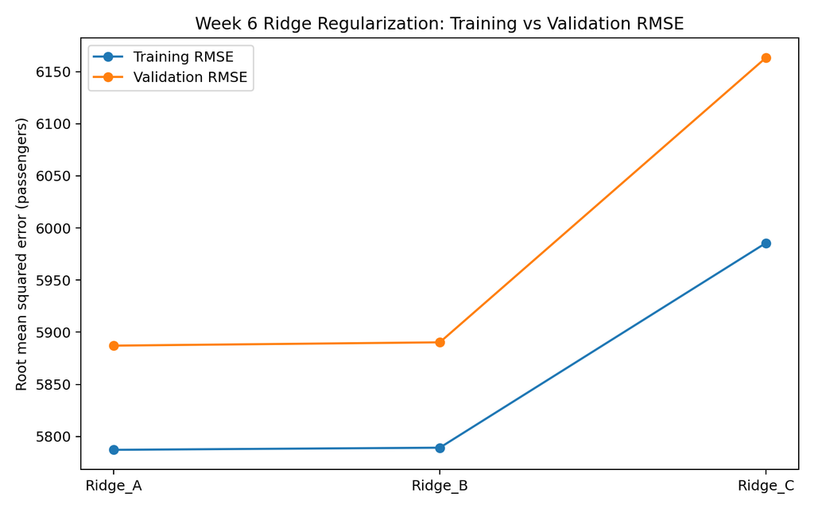

```
week6_figure_validation_actual_vs_predicted.png
```

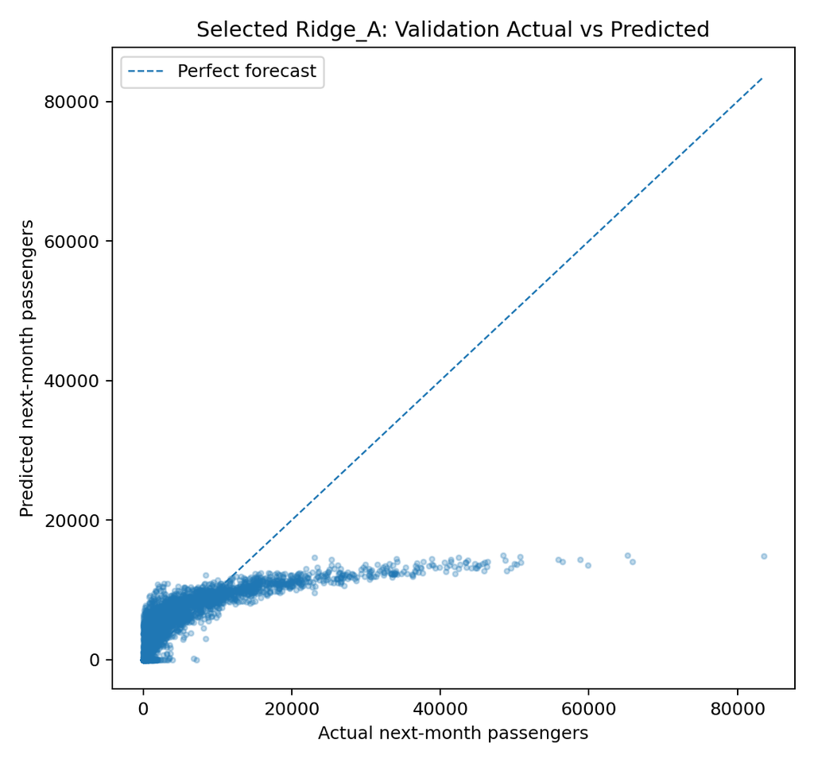

```python
for filename in [
    'week6_figure_mae_by_alpha.png',
    'week6_figure_rmse_by_alpha.png',
    'week6_figure_validation_actual_vs_predicted.png',
]:
    path = FIGURES / filename
    print(filename)
    display(Image(filename=str(path)))
```

## 7. Conclusion and final integrity checks

The Week 6 winner is a *provisional validation-selected model*.

- Generalization performance remains unknown until a later, explicitly authorized final test-set evaluation.
- The winning Ridge model on two PCA dimensions provides an interpretable benchmark in terms of model complexity, though the PCA components themselves are less transparent than original carrier/route variables.

The model does **not** receive future target values as predictors, and the Week 6 test partition is excluded from tuning and evaluation.

```python
from pathlib import Path
import numpy as np

assert len(results.metrics_table) == 3
assert (results.metrics_table['Training_MAE'] >= 0).all()
assert (results.metrics_table['Validation_MAE'] >= 0).all()
assert (results.metrics_table['Training_RMSE'] >= 0).all()
assert (results.metrics_table['Validation_RMSE'] >= 0).all()
assert (np.isfinite(results.metrics_table[['Training_MAE','Validation_MAE','Training_RMSE','Validation_RMSE','Training_R2','Validation_R2']].to_numpy())).all()
assert (TABLES / 'week6_winner_summary.json').exists()
assert (FIGURES / 'week6_figure_mae_by_alpha.png').exists()
assert (ROOT / 'Models' / 'week6' / 'week6_selected_ridge.joblib').exists()
print('All Week 6 checks passed.')
print('===== WEEK 6 END =====')
```

```
All Week 6 checks passed.
===== WEEK 6 END =====
```